# Lab 05 - Data Wrangling

# Learning goals

- Use the `merge()` function to join two datasets.
- Deal with missings and impute data.
- Identify relevant observations using `quantile()`.
- Practice your GitHub skills.

# Lab description

For this lab we will be dealing with the meteorological dataset `met`. In this case, we will use `data.table` to answer some questions regarding the `met` dataset, while at the same time practice your Git+GitHub skills for this project.

This markdown document should be rendered using `github_document` document.

# Part 1: Setup a Git project and the GitHub repository

1. Go to wherever you are planning to store the data on your computer, and create a folder for this project
2. In that folder, save [this template](https://github.com/JSC370/jsc370-2023/blob/main/labs/lab05/lab05-wrangling-gam.Rmd) as “README.Rmd”. This will be the markdown file where all the magic will happen.
3. Go to your GitHub account and create a new repository of the same name that your local folder has, e.g., “JSC370-labs”.
4. Initialize the Git project, add the “README.Rmd” file, and make your first commit.
5. Add the repo you just created on GitHub.com to the list of remotes, and push your commit to origin while setting the upstream.

Most of the steps can be done using command line:

```bash
# Step 1
cd ~/Documents
mkdir JSC370-labs
cd JSC370-labs

# Step 2
wget https://raw.githubusercontent.com/JSC370/jsc370-2023/main/labs/lab05/lab05-wrangling-gam.Rmd
mv lab05-wrangling-gam.Rmd README.Rmd
# if wget is not available,
curl https://raw.githubusercontent.com/JSC370/jsc370-2023/main/labs/lab05/lab05-wrangling-gam.Rmd --output README.Rmd

# Step 3
# Happens on github

# Step 4
git init
git add README.Rmd
git commit -m "First commit"

# Step 5
git remote add origin git@github.com:[username]/JSC370-labs
git push -u origin master
```

You can also complete the steps in R (replace with your paths/username when needed)

```r
# Step 1
setwd("~/Documents")
dir.create("JSC370-labs")
setwd("JSC370-labs")

# Step 2
download.file(
  "https://raw.githubusercontent.com/JSC370/jsc370-2023/main/labs/lab05/lab05-wrangling-gam.Rmd",
  destfile = "README.Rmd"
  )

# Step 3: Happens on Github

# Step 4
system("git init && git add README.Rmd")
system('git commit -m "First commit"')

# Step 5
system("git remote add origin git@github.com:[username]/JSC370-labs")
system("git push -u origin master")
```

Once you are done setting up the project, you can now start working with the MET data.

## Setup in R

1. Load the `data.table` (and the `dtplyr` and `dplyr` packages if you plan to work with those).

```r
library(data.table)
library(dplyr)
library(tidyverse)
library(leaflet)
```

2. Load the met data from https://github.com/JSC370/jsc370-2023/blob/main/labs/lab03/met_all.gz or (Use https://raw.githubusercontent.com/JSC370/jsc370-2023/main/labs/lab03/met_all.gz to download programmatically), and also the station data. For the latter, you can use the code we used during lecture to pre-process the stations data:

```r
fn <- "https://raw.githubusercontent.com/JSC370/jsc370-2023/main/labs/lab03/met_all.gz"
if (!file.exists("met_all.gz"))
  download.file(fn, destfile = "met_all.gz")
met <- data.table::fread("met_all.gz")
```

```r
# Download the data
stations <- fread("ftp://ftp.ncdc.noaa.gov/pub/data/noaa/isd-history.csv")
stations[, USAF := as.integer(USAF)]
# Dealing with NAs and 999999
stations[, USAF   := fifelse(USAF == 999999, NA_integer_, USAF)]
stations[, CTRY   := fifelse(CTRY == "", NA_character_, CTRY)]
stations[, STATE  := fifelse(STATE == "", NA_character_, STATE)]

# Selecting the three relevant columns, and keeping unique records
stations <- unique(stations[, list(USAF, CTRY, STATE)])

# Dropping NAs
stations <- stations[!is.na(USAF)]

# Removing duplicates
stations[, n := 1:.N, by = .(USAF)]
stations <- stations[n == 1,][, n := NULL]
```

3. Merge the data as we did during the lecture.

```r
dat <- merge(
  x = stations,
  y = met,
  by.x = "USAF",
  by.y = "USAFID",
  all.x = FALSE,
  all.y = TRUE
)
```

## Question 1: Representative station for the US

Across all weather stations, what is the median station in terms of temperature, wind speed, and atmospheric pressure? Look for the three weather stations that best represent continental US using the `quantile()` function. Do these three coincide?

```r
dat_avg <- dat[, .(temp_avg = mean(temp, na.rm=TRUE),
       wind.sp_avg = mean(wind.sp, na.rm=TRUE),
       atm.press_avg = mean(atm.press, na.rm = TRUE),
       lat_avg = mean(lat, na.rm = TRUE),
       lon_avg = mean(lon, na.rm = TRUE)), by = "USAF"]
```

```r
# Alternative
dat_avg <- dat %>%
  group_by("USAF") %>%
  summarise(
    across(
      c(temp,wind.sp,atm.press, lon, lat),
      function(x) mean(x, na.rm = TRUE)
    )
  )
```

```r
summary(dat_avg)
```

[output not shown]

```r
med <- dat_avg %>%
  summarise(across(2:4,
            function(x) quantile(x, probs = .5, na.rm=TRUE)))
```

```r
# Best Wind Speed
dat_avg[dat_avg$wind.sp_avg == med$wind.sp_avg,]
```

```
##      USAF temp_avg wind.sp_avg atm.press_avg lat_avg lon_avg
## 1: 720929 17.43278    2.461838           NaN  45.506 -91.981
```

```r
# Best Temp
dat_avg %>%
  mutate(temp_diff = abs(temp_avg - med %>% pull(temp_avg))) %>%
  arrange(temp_diff) %>%
  slice(1)
```

```
##      USAF temp_avg wind.sp_avg atm.press_avg lat_avg lon_avg   temp_diff
## 1: 720458 23.68173    1.209682           NaN  37.751 -82.637 0.002328907
```

```r
# Best Atm Press
dat_avg %>%
  mutate(temp_diff = abs(atm.press_avg - med %>% pull(atm.press_avg))) %>%
  arrange(temp_diff) %>%
  slice(1)
```

```
##      USAF temp_avg wind.sp_avg atm.press_avg  lat_avg   lon_avg    temp_diff
## 1: 723200 25.82436    1.537661      1014.692 34.34823 -85.16164 0.0005376377
```

```r
dat %>% select(USAF, lon, lat) %>%
  distinct() %>%
  filter(USAF %in% c(720929, 720458, 723200))
```

```
##      USAF     lon    lat
## 1: 720458 -82.637 37.751
## 2: 720929 -91.981 45.506
## 3: 723200 -85.167 34.350
## 4: 723200 -85.161 34.348
## 5: 723200 -85.158 34.351
```

Knit the document, commit your changes, and save it on GitHub. Don’t forget to add `README.md` to the tree, the first time you render it.

## Question 2: Representative station per state

Just like the previous question, you are asked to identify what is the most representative, the median, station per state. This time, instead of looking at one variable at a time, look at the euclidean distance. If multiple stations show in the median, select the one located at the lowest latitude.

```r
state_avg <- dat[, .(temp_med = median(temp, na.rm=TRUE),
       wind.sp_med = median(wind.sp, na.rm=TRUE),
       atm.press_med = median(atm.press, na.rm = TRUE)), by = "STATE"]
```

```r
# Add State For each station
dat_avg_state <- merge(
  x = dat_avg,
  y = dat[, c("USAF", "STATE")],
  by.x = "USAF",
  by.y = "USAF",
  all.x = TRUE,
  all.y = FALSE
)
dat_avg_state <- dat_avg_state %>% distinct()

# Merge with average temperature
dat_avg_with_state_mean <- merge(
  x = dat_avg_state,
  y = state_avg,
  by.x = "STATE",
  by.y = "STATE",
  all.x = TRUE,
  all.y = FALSE
)
```

```r
dis <- function(A, B, C, meanA, meanB, meanC) {
  result <- sqrt((A - meanA)^2 + (B - meanB)^2 + (C - meanC)^2)
  return(result)
}
# Add diff
dat_avg_with_state_mean <- dat_avg_with_state_mean %>%
  mutate(diff = dis(temp_avg, wind.sp_avg, atm.press_avg, temp_med, wind.sp_med, atm.press_med))

best_station <- dat_avg_with_state_mean %>% group_by(STATE) %>%
  summarise(diff = min(diff, na.rm = TRUE))
# Result
q2 <- merge(
  x = dat_avg_with_state_mean,
  y = best_station,
  by.x = c("diff", "STATE"),
  by.y = c("diff", "STATE"),
  all.x = FALSE,
  all.y = FALSE
)

q2 %>% select(STATE, USAF)
```

```
##     STATE   USAF
##  1:    SD 726590
##  2:    DE 724093
##  3:    AL 722267
##  4:    GA 722250
##  5:    OK 723560
##  6:    MO 724459
##  7:    AR 723407
##  8:    FL 722060
##  9:    OH 724298
## 10:    MS 723306
## 11:    KY 724238
## 12:    NE 725560
## 13:    IN 724386
## 14:    TN 723280
```

[output cut: 33 more lines]

Knit the doc and save it on GitHub.

## Question 3: In the middle?

For each state, identify what is the station that is closest to the mid-point of the state. Combining these with the stations you identified in the previous question, use `leaflet()` to visualize all ~100 points in the same figure, applying different colors for those identified in this question.

```r
state_mid <- dat[, .(lon = mean(lon, na.rm=TRUE),
       lat = mean(lat, na.rm=TRUE)), by = "STATE"]


# Merge with mid position of state
dat_avg_with_state_mean_position <- merge(
  x = dat_avg_state,
  y = state_mid,
  by.x = "STATE",
  by.y = "STATE",
  all.x = TRUE,
  all.y = FALSE
)
```

```r
dis2 <- function(A, B, meanA, meanB) {
  result <- sqrt((A - meanA)^2 + (B - meanB)^2)
  return(result)
}
# Add diff
dat_avg_with_state_mean_position <- dat_avg_with_state_mean_position %>%
  mutate(diff = dis2(lat_avg, lon_avg, lat, lon))

closest_station <- dat_avg_with_state_mean_position %>% group_by(STATE) %>%
  summarise(diff = min(diff, na.rm = TRUE))

# Result
q3 <- merge(
  x = dat_avg_with_state_mean_position,
  y = closest_station,
  by.x = c("diff", "STATE"),
  by.y = c("diff", "STATE"),
  all.x = FALSE,
  all.y = FALSE
)


q3 %>% select(STATE, USAF, lat_avg, lon_avg)
```

```
##     STATE   USAF  lat_avg    lon_avg
##  1:    DE 724088 39.13291  -75.46697
##  2:    SC 723105 33.96470  -80.80005
##  3:    NC 722201 35.58208  -79.10100
##  4:    RI 725074 41.59700  -71.41200
##  5:    MI 725405 43.32200  -84.68800
##  6:    CT 725027 41.51000  -72.82800
##  7:    ME 726073 44.53300  -69.66723
##  8:    NH 726155 43.56721  -71.43251
##  9:    MD 722244 38.98100  -76.92200
## 10:    WI 726452 44.35900  -89.83701
## 11:    FL 722014 28.47400  -82.45400
## 12:    VT 726145 44.20400  -72.56200
## 13:    MA 725068 41.87600  -71.02100
## 14:    IA 725466 41.69100  -93.56600
```

[output cut: 35 more lines]

```r
# Marker is Center, Circle is Best Station in Q2
leaflet() %>%
  addProviderTiles("OpenStreetMap") %>%
  addCircles(lat=~lat_avg, lng=~lon_avg, color = "BLUE", data = q2) %>%
  addMarkers(lat=~lat_avg, lng=~lon_avg, data = q3)
```

[interactive chart not shown]

Knit the doc and save it on GitHub.

## Question 4: Means of means

Using the `quantile()` function, generate a summary table that shows the number of states included, average temperature, wind-speed, and atmospheric pressure by the variable “average temperature level,” which you’ll need to create.

Start by computing the states’ average temperature. Use that measurement to classify them according to the following criteria:

- low: temp < 20
- Mid: temp >= 20 and temp < 25
- High: temp >= 25

```r
new_dat <- dat[, .(temp_avg = mean(temp, na.rm = TRUE),
        wind.sp_avg = mean(wind.sp, na.rm = TRUE),
        atm.press_avg = mean(atm.press, na.rm = TRUE)),by = STATE]
new_dat <- new_dat[,label := case_when(temp_avg < 20 ~ "low", temp_avg >= 20 & temp_avg < 25 ~ "mid",
                          TRUE ~ "High")]
```

Once you are done with that, you can compute the following:

- Number of entries (records),
- Number of NA entries,
- Number of stations,
- Number of states included, and
- Mean temperature, wind-speed, and atmospheric pressure.

All by the levels described before.

```r
table(new_dat$label)
```

```
##
## High  low  mid
##   12   11   25
```

```r
new_dat %>% group_by(label) %>%
  summarise(n_state = n(),
            mean_wind = quantile(wind.sp_avg, probs = .5, na.rm=TRUE),
            mean_atm = quantile(atm.press_avg, probs = .5, na.rm=TRUE),
            mean_temp = quantile(temp_avg, probs = .5, na.rm=TRUE),
            )
```

```
## # A tibble: 3 × 5
##   label n_state mean_wind mean_atm mean_temp
##   <chr>   <int>     <dbl>    <dbl>     <dbl>
## 1 High       12      2.17    1015.      26.5
## 2 low        11      2.19    1015.      18.7
## 3 mid        25      2.32    1015.      22.3
```

Knit the document, commit your changes, and push them to GitHub.

## Question 5: Advanced Regression

Let’s practice running regression models with smooth functions on X. We need the `mgcv` package and `gam()` function to do this.

- using your data with the median values per station, examine the association between median temperature (y) and median wind speed (x). Create a scatterplot of the two variables using ggplot2. Add both a linear regression line and a smooth line.
- fit both a linear model and a spline model (use `gam()` with a cubic regression spline on wind speed). Summarize and plot the results from the models and interpret which model is the best fit and why.

```r
library(mgcv)
library(gam)
```

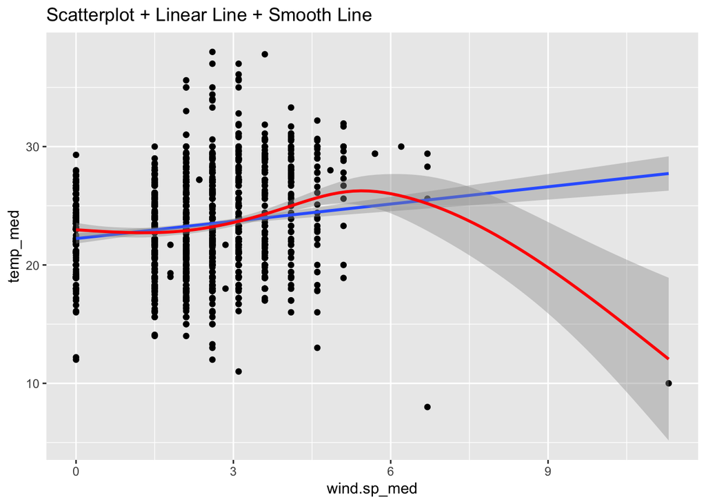

```r
dat_med <- dat[, .(temp_med = median(temp, na.rm = TRUE),
        wind.sp_med = median(wind.sp, na.rm = TRUE),
        atm.press_med = median(atm.press, na.rm = TRUE)),by = USAF]
dat_med %>% ggplot(aes(x = wind.sp_med, y = temp_med)) + geom_point() +
  geom_smooth(method = "lm") + geom_smooth(color = "RED") + labs(title = "Scatterplot + Linear Line + Smooth Line")
```

```r
linear <- lm(temp_med ~ wind.sp_med ,data = dat_med)
gam_co <- gam(temp_med ~ s(wind.sp_med,5) ,data = dat_med)
anova(linear, gam_co)
```

```
## Analysis of Variance Table
##
## Model 1: temp_med ~ wind.sp_med
## Model 2: temp_med ~ s(wind.sp_med, 5)
##   Res.Df   RSS     Df Sum of Sq      F   Pr(>F)
## 1   1577 23362
## 2   1573 22647 4.0001    715.68 12.427 5.92e-10 ***
## ---
## Signif. codes:  0 '***' 0.001 '**' 0.01 '*' 0.05 '.' 0.1 ' ' 1
```